# Tracking team strength of Houston Rockets

Suvro Mukherjee

2025-04-13

```r
library(tidyverse)
library(readxl)
library(pomp)
library(doFuture)
library(future.apply)
library(iterators)
library(tsibble)
library(fabletools)
library(feasts)
library(forecast)
```

## Overview

For the final project, our team analyses two seasons of the Houston Rockets and attempt to understand and model their performance in the NBA. The National Basketball Association (NBA) is a professional basketball league in North America, consisting of 30 teams. Each team plays 82 games in the regular season, with games scheduled over several months. In our analysis we track the progression of the team’s ELO rating and the impact of statistics such as Box Plus-Minus(BPM) among others to gain an in-depth idea of modelling a certain basketball team’s momentum.

Our data is sourced and scraped from the ‘Basketball Reference’ website which provides detailed game-by-game data.

```
## # A tibble: 6 × 7
##   Season Date              Visitor        PTS_V Home                 PTS_H OT
##    <dbl> <chr>             <chr>          <dbl> <chr>                <dbl> <chr>
## 1   2021 Sat, Oct 23, 2021 Atlanta Hawks     95 Cleveland Cavaliers    101 <NA>
## 2   2021 Wed, Oct 27, 2021 Atlanta Hawks    102 New Orleans Pelicans    99 <NA>
## 3   2021 Thu, Oct 28, 2021 Atlanta Hawks    111 Washington Wizards     122 <NA>
## 4   2021 Sat, Oct 30, 2021 Atlanta Hawks     94 Philadelphia 76ers     122 <NA>
## 5   2021 Wed, Oct 20, 2021 Boston Celtics   134 New York Knicks        138 2OT
## 6   2021 Sun, Oct 24, 2021 Boston Celtics   107 Houston Rockets         97 <NA>
```

### ELO Rating

Elo ratings are a system originally developed for chess to rate player skill, but now widely used in sports (including the NBA). Each team starts with a base rating (e.g., 1500), and ratings are updated after each game based on the outcome and the opponent’s strength. Winning against a strong team boosts your rating more than beating a weaker team. As this metric is proportional to the team strength, we incorporate this as the principal observed process.

```r
update_elo <- function(rating1, rating2, result, K = 20) {
  E1 <- 1 / (1 + 10^((rating2 - rating1) / 400))  # Expected score for team 1
  E2 <- 1 / (1 + 10^((rating1 - rating2) / 400))  # Expected score for team 2

  if (result == 1) {  # Team 1 wins
    rating1_new <- rating1 + K * (1 - E1)
    rating2_new <- rating2 + K * (0 - E2)
  } else {  # Team 2 wins
    rating1_new <- rating1 + K * (0 - E1)
    rating2_new <- rating2 + K * (1 - E2)

  }

  return(c(rating1_new, rating2_new))
}
```

We analyze the data starting from the 2023 season.

```r
elo_ratings <- data.frame(Team = unique(c(matchups$Visitor, matchups$Home)),
                          Elo = rep(1500, length(unique(c(matchups$Visitor, matchups$Home)))))

matchup23 <- matchups[matchups$Season>=2023,]
matchup23$Result <- ifelse(matchup23$PTS_V > matchup23$PTS_H, 1, 2)

elo_v <- c()
elo_h <- c()

# Loop through matchups to update Elo ratings
for (i in 1:nrow(matchup23)) {
  team1 <- matchup23$Visitor[i]
  team2 <- matchup23$Home[i]

  # Get current ratings using match()
  rating1 <- elo_ratings$Elo[match(team1, elo_ratings$Team)]
  rating2 <- elo_ratings$Elo[match(team2, elo_ratings$Team)]

  # Update Elo ratings
  updated_ratings <- update_elo(rating1, rating2, matchup23$Result[i])

  # Save updated ratings back into the data frame
  elo_ratings$Elo[elo_ratings$Team == team1] <- updated_ratings[1]
  elo_ratings$Elo[elo_ratings$Team == team2] <- updated_ratings[2]

  elo_v <- c(elo_v,updated_ratings[1])
  elo_h <- c(elo_h,updated_ratings[2])

}

matchup23$ELO_V <- elo_v
matchup23$ELO_H <- elo_h
```

We subset the data to analyse the performance of the Houston Rockets from the 2023 season and integrate it with the aggregate BPM of the starting lineup:

[output not shown]

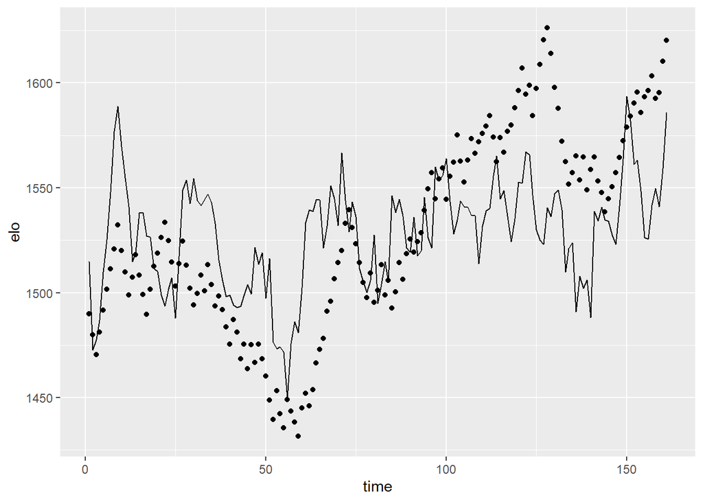

```r
#r_23 <- rockets_matchups[rockets_matchups$Season>=2023,]
r_23 <- matchup23[(matchup23$Visitor=="Houston Rockets")|(matchup23$Home=="Houston Rockets"),]

n <- nrow(r_23)
rockets_elo_df <- data.frame(date = as.Date(rep(NA, n)), elo = rep(NA, n), opp_elo = rep(NA, n))
row_counter <- 1

for (i in 1:n) {
  if (r_23[i, 3] == "Houston Rockets") {
    rockets_elo_df[row_counter, ] <- list(as.Date(r_23[[i, 2]],format = "%a, %b %d, %Y"), as.numeric(r_23[i, 9]), as.numeric(r_23[i,10]))
    row_counter <- row_counter + 1
  } else if (r_23[i, 5] == "Houston Rockets") {
    rockets_elo_df[row_counter, ] <- list(as.Date(r_23[[i, 2]],format = "%a, %b %d, %Y"), as.numeric(r_23[i, 10]),
                                          as.numeric(r_23[i,9]))
    row_counter <- row_counter + 1
  }
}

# Remove unused rows
rockets_elo_df <- rockets_elo_df[1:(row_counter - 1), ]

rockets_elo_df["time"] <- seq(1,161,by=1)
#adding in initial elo at time 0
inital <- data.frame(date = as.Date(10/24/2023,
  format = "%m/%d/%y"),elo=1500,opp_elo=1500,time=0)
rockets_elo_df2 <- rbind(rockets_elo_df,inital)
# ggplot(rockets_elo_df2,aes(time,elo))+geom_line()
```

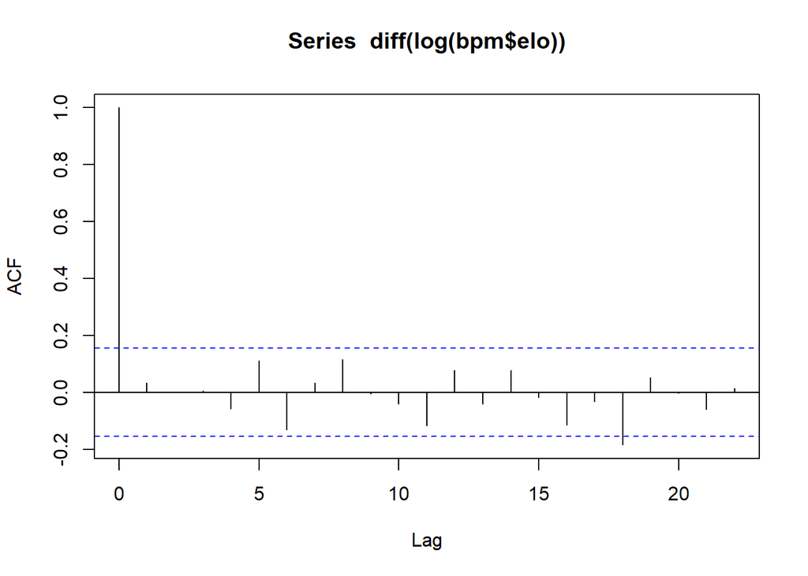

```r
aic_table <- function(data,P,Q){
table <- matrix(NA,(P+1),(Q+1))
for(p in 0:P) {
for(q in 0:Q) {
table[p+1,q+1] <- arima(data,order=c(p,1,q))$aic
}
}
dimnames(table) <- list(paste("AR",0:P, sep=""),
paste("MA",0:Q,sep=""))
table
}
bpm_aic_table <- aic_table(log(bpm$elo),4,5)
require(knitr)
kable(bpm_aic_table,digits=2)
```

|  | MA0 | MA1 | MA2 | MA3 | MA4 | MA5 |
| --- | --- | --- | --- | --- | --- | --- |
| AR0 | -1165.98 | -1164.26 | -1162.26 | -1160.32 | -1158.89 | -1160.04 |
| AR1 | -1164.26 | -1162.26 | -1160.26 | -1158.27 | -1158.76 | -1158.84 |
| AR2 | -1162.26 | -1161.24 | -1166.27 | -1164.36 | -1162.21 | -1161.04 |
| AR3 | -1160.29 | -1158.27 | -1156.26 | -1157.60 | -1155.67 | -1161.44 |
| AR4 | -1158.73 | -1159.35 | -1164.12 | -1163.02 | -1162.84 | -1161.73 |

```r
library(forecast)
arima_22 <- Arima(log(bpm$elo),order=c(2,1,2))
arima_22
```

```
## Series: log(bpm$elo)
## ARIMA(2,1,2)
##
## Coefficients:
##           ar1      ar2     ma1     ma2
##       -0.3948  -0.8845  0.4700  0.9876
## s.e.   0.0669   0.0673  0.0396  0.0693
##
## sigma^2 = 3.832e-05:  log likelihood = 588.13
## AIC=-1166.27   AICc=-1165.88   BIC=-1150.89
```

```r
polyroot(c(1,-coef(arima_22)[c("ar1","ar2")]))
```

```
## [1] -0.223198+1.039589i -0.223198-1.039589i
```

```r
polyroot(c(1,-coef(arima_22)[c("ma1","ma2")]))
```

```
## [1]  0.7960473-2.176451e-18i -1.2719885+2.176451e-18i
```

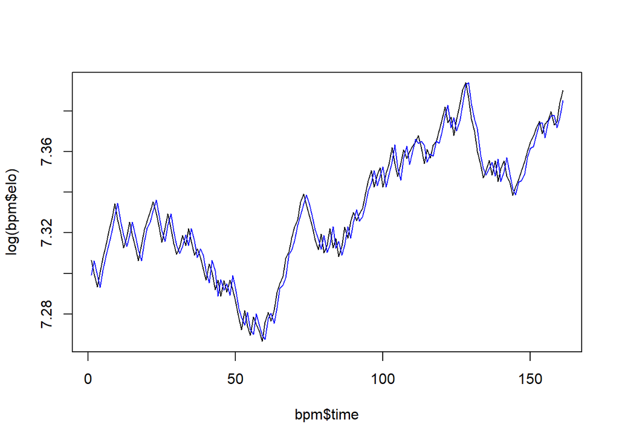

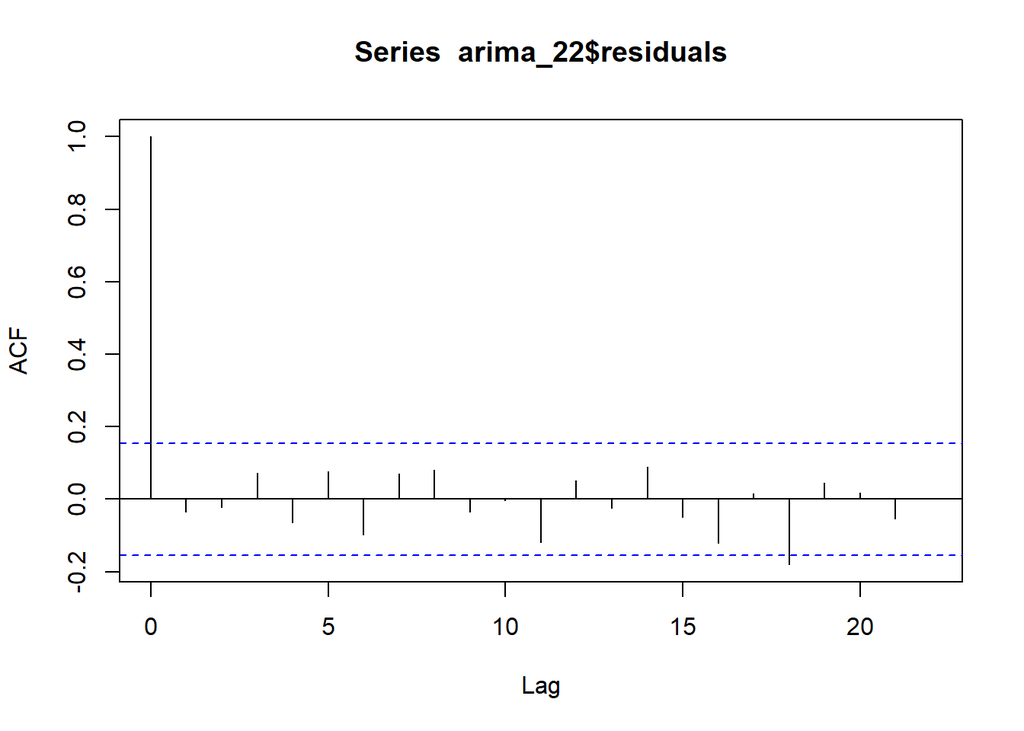

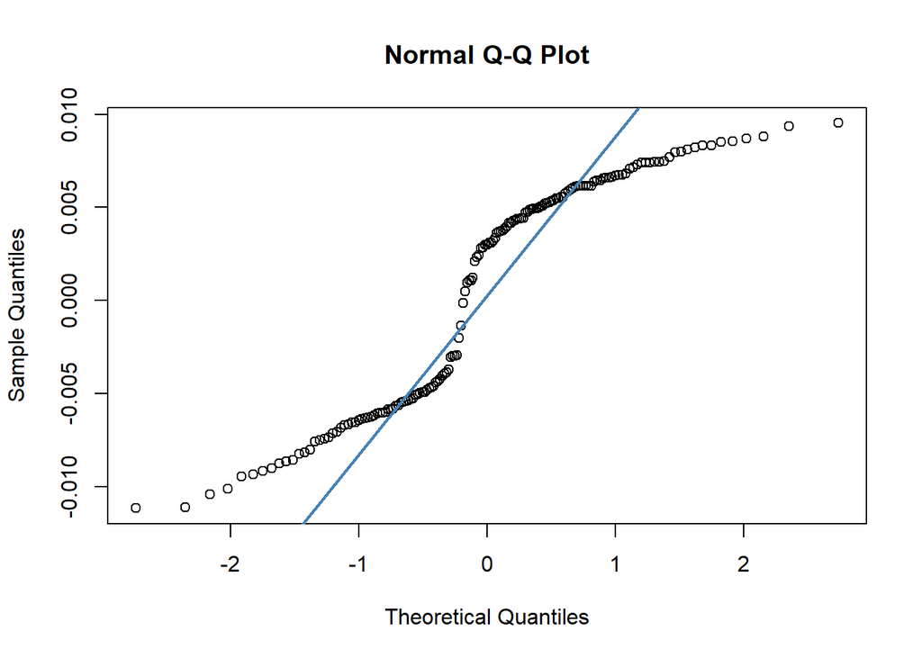

We conduct a STL decomposition and analysis. As this data is event-based(date of games), we fill the irregular data to to support the decomposition.

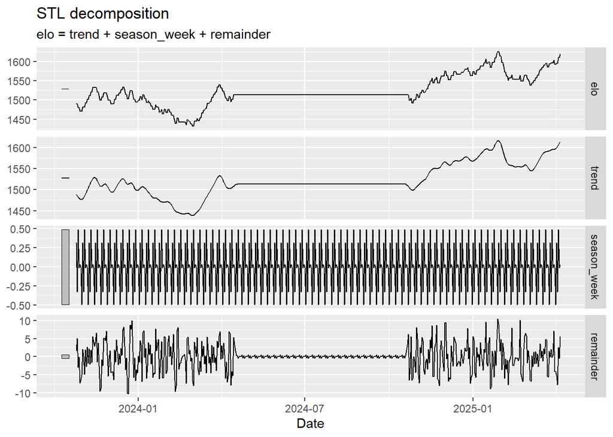

```r
rproc <- Csnippet("
  team_strength += beta1 *last5_bpm - alpha * (team_strength - 1500)  + rnorm(0, sigma);

  double p_win = 1.0 / (1.0 + pow(10, (opp_strength - team_strength) / 400));
  int sim_win = rbinom(1, p_win);

  if (sim_win == 1) {
    team_strength += 20 * (1 - 1/(1+pow(10, (opp_strength - team_strength)/400)));
  } else {
    team_strength -= 20 * (1 - 1/(1+pow(10, (opp_strength - team_strength)/400)));
  }
")

dmeas <- Csnippet("
  double p;

  double team_score = team_strength / 100.0;
  double opp_score = opp_strength / 100.0;
  double hca = home_court_avd / 100.0;

  double max_val = fmax(team_score, opp_score);

  if (home == 1){
    team_score += hca;
  }

  p = exp(team_score - max_val) / (exp(team_score - max_val) + exp(opp_score - max_val));

  lik = dbinom(Win, 1, p, give_log);
")

rmeas <- Csnippet("
double p;
  if (home == 1){
  p = exp(home_court_avd + team_strength - opp_strength) / (1 + exp(home_court_avd + team_strength - opp_strength));
  }
  else{
  p = exp(team_strength - opp_strength) / (1 + exp(team_strength - opp_strength));
  }
  Win = rbinom(1, p);
")

init <- Csnippet("
  team_strength = 1500;
")

bpm %>% select(time,Win,Home,`Last 5 Games BPM`,opp_elo,elo) -> red_bpm

nba_pomp <- pomp(
  data = red_bpm,
  times = "time",
  t0 = 1,
  rprocess = euler(step.fun = rproc, delta.t = 1),
  rmeasure = rmeas,
  dmeasure = dmeas,
  rinit = init,
  statenames = "team_strength",
  paramnames = c("beta1", "sigma", "home_court_avd","alpha"),
  partrans = parameter_trans(
    log = c("alpha")
  ),
  covar = covariate_table(
    times = red_bpm$time,
    last5_bpm = red_bpm$`Last 5 Games BPM`,
    opp_strength = red_bpm$opp_elo,
    home = red_bpm$Home
  ),
  covarnames = c("last5_bpm","opp_strength","home")
)
```

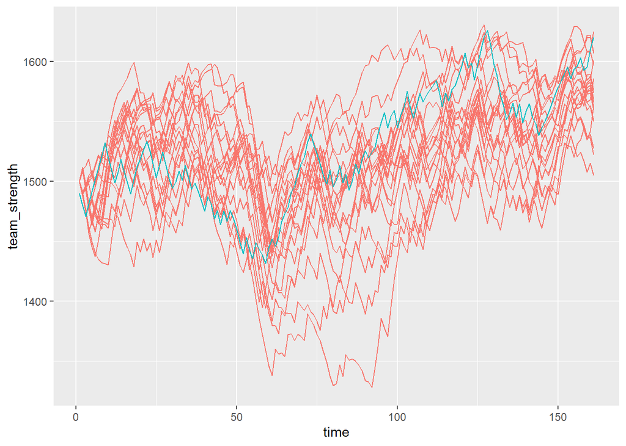

```r
nba_pomp |>
  simulate(
    params=c(beta1=.5,sigma=1,home_court_avd=40,alpha=.05),
    nsim=20,format="data.frame",include.data=TRUE
  ) -> sims

sims |>
  ggplot(aes(x=time,y=team_strength,group=.id,color=.id=="data"))+
  geom_line()+
  geom_line(aes(x=time,y=elo))+
  guides(color="none")
```

Conducting local search:

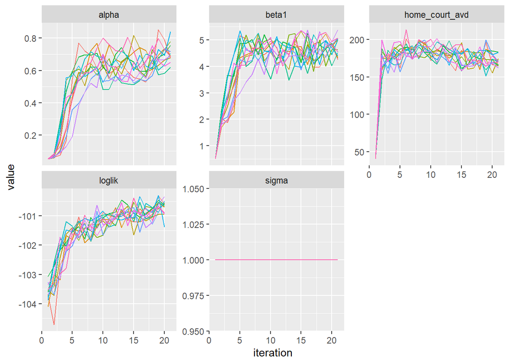

```r
coef(nba_pomp) <- c(beta1=0.5, sigma=1, home_court_avd=40, alpha=0.05)
fixed_params <- coef(nba_pomp,c("sigma"))

plan(multisession)
ncpu <- nbrOfWorkers()
local_mifs <- future_lapply(future.seed=TRUE,seq_len(ncpu), function(i) {
  nba_pomp |>
    mif2(
      Np=700, Nmif=20,
      cooling.fraction.50=0.5,
      rw.sd=rw_sd(beta1=0.5, home_court_avd=40, alpha=0.05)
    )
})

local_mifs_combined <- do.call(c, local_mifs)

local_mifs_combined |>
  traces(pars=c("loglik","beta1","sigma","home_court_avd","alpha")) |>
  melt() |>
  ggplot(aes(x=iteration,y=value,group=.L1,color=factor(.L1)))+
  geom_line()+
  guides(color="none")+
  facet_wrap(~name,scales="free_y")
```

Conducting global search:

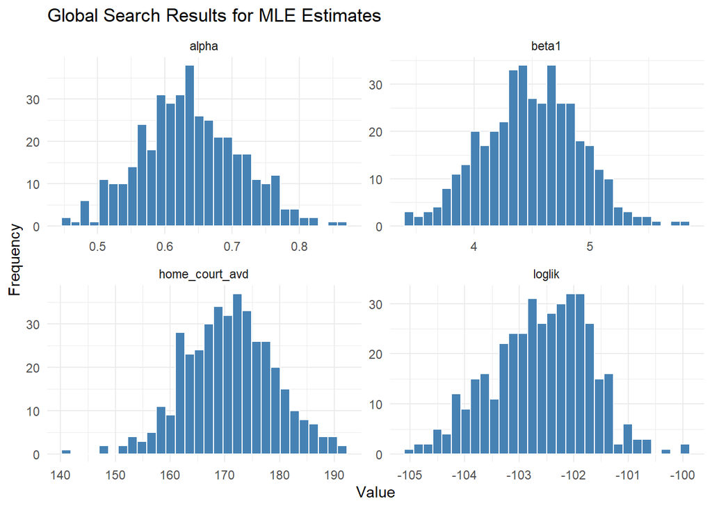

```r
set.seed(2062379496)
runif_design(
lower=c(beta1=0,home_court_avd=200,alpha=0),
upper=c(beta1=1,home_court_avd=250,alpha=1),
nseq=400
) -> guesses

mf1 <- local_mifs[[1]]

foreach(guess=iter(guesses,"row"), .combine=rbind,
.options.future=list(seed=1270401374)
) %dofuture% {
  mf1 |>
    mif2(params=c(guess,fixed_params)) |>
    mif2(Nmif=20) -> mf
  replicate(
  10,
  mf |> pfilter(Np=700) |> logLik()
  ) |>
    logmeanexp(se=TRUE) -> ll
  mf |> coef() |> bind_rows() |>
    bind_cols(loglik=ll[1],loglik.se=ll[2])
} -> results

results |>
  pivot_longer(cols = c(beta1, home_court_avd, alpha, loglik),
               names_to = "parameter", values_to = "value") |>
  ggplot(aes(x = value)) +
  geom_histogram(bins = 30, fill = "steelblue", color = "white") +
  facet_wrap(~parameter, scales = "free", ncol = 2) +
  theme_minimal() +
  labs(title = "Global Search Results for MLE Estimates",
       x = "Value", y = "Frequency")
```